# Chapter 4: Random Variables and Probability Distributions

2026-02-25

# 1 Random Variables

A **random variable** is a function that maps each outcome of a random experiment to a numerical value.

> **Example:** Roll a die. The number that lands face-up is a random variable — it takes values 1–6, each with probability 1/6.

## 1.1 Discrete vs Continuous Random Variables

| Type | Values | Examples |
| --- | --- | --- |
| **Discrete** | Countable (0, 1, 2, …) | Number of heads in 10 coin flips; number of calls per hour |
| **Continuous** | Any value in an interval | Height, weight, reaction time, temperature |

The distinction matters because it determines which mathematical tool — PMF or PDF — describes the distribution.

## 1.2 Probability Mass and Density Functions

### 1.2.1 PMF — for Discrete Variables

The **Probability Mass Function** $p(x)$ gives the *exact* probability of each possible value:

$$p(x) = P(X = x), \quad \sum_{\text{all }
x} p(x) = 1$$

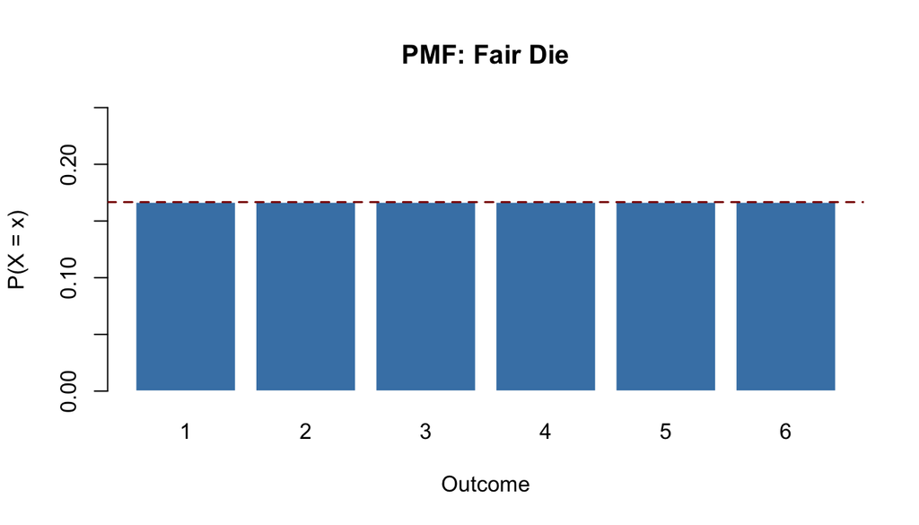

```r
# PMF of a fair die
x   <- 1:6
pmf <- rep(1/6, 6)

barplot(pmf,
        names.arg = x,
        col       = "steelblue",
        border    = "white",
        main      = "PMF: Fair Die",
        xlab      = "Outcome",
        ylab      = "P(X = x)",
        ylim      = c(0, 0.25))
abline(h = 1/6, col = "darkred", lty = 2, lwd = 1.5)
```

### 1.2.2 PDF — for Continuous Variables

The **Probability Density Function** $f(x)$ does **not** give point probabilities (those are always 0 for continuous variables). Instead, probability is the **area under the curve**:

$$P(a \leq X \leq b) = \int_a^b f(x)\, dx,
\quad \int_{-\infty}^{\infty} f(x)\, dx = 1$$

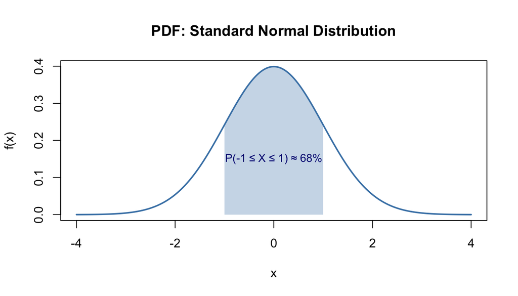

```r
# PDF of a Standard Normal distribution
x_vals <- seq(-4, 4, length.out = 300)
y_vals <- dnorm(x_vals)

plot(x_vals, y_vals,
     type = "l", lwd = 2, col = "steelblue",
     main = "PDF: Standard Normal Distribution",
     xlab = "x", ylab = "f(x)")

# Shade area between -1 and 1
x_shade <- seq(-1, 1, length.out = 200)
polygon(c(-1, x_shade, 1), c(0, dnorm(x_shade), 0),
        col = rgb(0.27, 0.51, 0.71, 0.3), border = NA)
text(0, 0.15, "P(-1 ≤ X ≤ 1) ≈ 68%", cex = 0.9, col = "navy")
```

# 2 Discrete Distributions

## 2.1 Binomial Distribution

Models the number of **successes** in $n$ independent yes/no trials, each with success probability $p$.

$$X \sim \text{Bin}(n, p), \quad P(X = k)
= \binom{n}{k} p^k (1-p)^{n-k}$$

- **Mean:** $\mu = np$
- **Variance:** $\sigma^2 = np(1-p)$

**When to use:** Fixed number of trials, each independent, same $p$ each time.  
**Example:** Number of students who pass out of 30, assuming each has a 70% pass rate.

## 2.2 Poisson Distribution

Models the number of **rare events** occurring in a fixed interval of time or space.

$$X \sim \text{Poisson}(\lambda), \quad
P(X = k) = \frac{e^{-\lambda} \lambda^k}{k!}$$

- **Mean:** $\mu = \lambda$
- **Variance:** $\sigma^2 = \lambda$ ← mean equals variance (a unique property)

**When to use:** Events happen at a constant average rate; occurrences are independent.  
**Example:** Number of customer calls received per hour; number of typos per page.

## 2.3 Poisson Approximation to Binomial

When $n$ is **large** and $p$ is **small** (rare events), $\text{Bin}(n, p) \approx \text{Poisson}(\lambda = np)$.

| Condition | Rule of thumb |
| --- | --- |
| Large $n$ | $n \geq 20$ |
| Small $p$ | $p \leq 0.05$ |

**Example:** Defective items in mass production — 10,000 items with a 0.1% defect rate.

# 3 Continuous Distributions

## 3.1 Uniform Distribution

All values in the interval $[a, b]$ are **equally likely**.

$$X \sim \text{Uniform}(a, b), \quad f(x)
= \frac{1}{b - a}, \quad a \leq x \leq b$$

- **Mean:** $\mu = \frac{a + b}{2}$
- **Variance:** $\sigma^2 = \frac{(b-a)^2}{12}$

**Example:** Random arrival time within a 60-minute window; random number generation.

## 3.2 Normal Distribution

The **bell-shaped** distribution, symmetric around the mean — arguably the most important distribution in statistics.

$$X \sim \mathcal{N}(\mu, \sigma^2), \quad
f(x) = \frac{1}{\sigma\sqrt{2\pi}}
\exp\!\left(-\frac{(x-\mu)^2}{2\sigma^2}\right)$$

Key properties:

| Region | Probability |
| --- | --- |
| $\mu \pm 1\sigma$ | ≈ 68% |
| $\mu \pm 2\sigma$ | ≈ 95% |
| $\mu \pm 3\sigma$ | ≈ 99.7% |

**Example:** Exam scores, IQ scores, measurement errors, biological measurements.

# 4 Limit Theorems

## 4.1 Central Limit Theorem (CLT)

> **Regardless of the population’s shape**, the distribution of the **sample mean** $\bar{X}$ approaches a Normal distribution as sample size $n$ increases.

$$\bar{X} \xrightarrow{d}
\mathcal{N}\!\left(\mu,\, \frac{\sigma^2}{n}\right) \quad \text{as } n
\to \infty$$

This is why the Normal distribution appears so often in practice — it emerges naturally from averages, even when individual data points are not Normal.

## 4.2 Implications for Inference

The CLT is the engine behind most classical statistical methods:

- **Confidence intervals** are built using the Normal approximation to $\bar{X}$.
- **Hypothesis tests** (z-tests, t-tests) rely on the sampling distribution of $\bar{X}$ being approximately Normal.
- It justifies using Normal-based methods even with non-Normal raw data, provided $n$ is large enough (rule of thumb: $n \geq 30$).

# 5 R Coverage

## 5.1 `dbinom()` and `rbinom()`

```r
# --- dbinom(): theoretical probability ---
# P(X = 3) where X ~ Bin(10, 0.5)
dbinom(3, size = 10, prob = 0.5)
```

```
#> [1] 0.1171875
```

```r
# P(X <= 3): cumulative probability
pbinom(3, size = 10, prob = 0.5)
```

```
#> [1] 0.171875
```

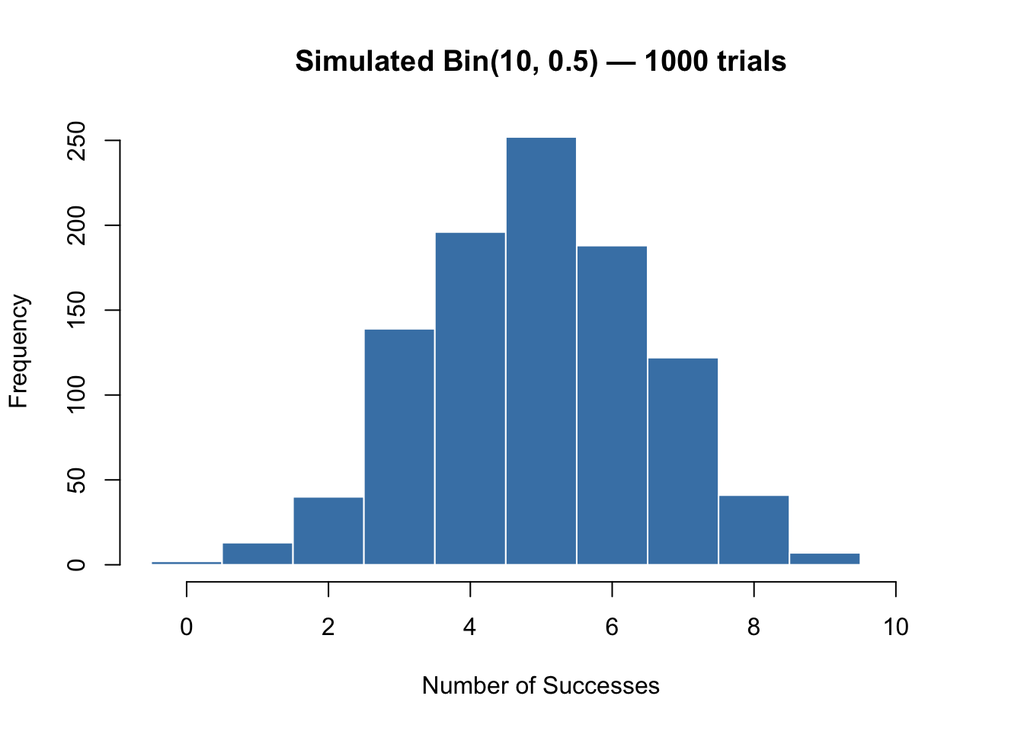

```r
# --- rbinom(): simulate binomial data ---
set.seed(42)
sim_binom <- rbinom(1000, size = 10, prob = 0.5)

hist(sim_binom,
     breaks = 0:11 - 0.5,
     col    = "steelblue",
     border = "white",
     main   = "Simulated Bin(10, 0.5) — 1000 trials",
     xlab   = "Number of Successes",
     ylab   = "Frequency")
```

## 5.2 `dpois()` and `rpois()`

```r
# --- dpois(): P(X = k) where X ~ Poisson(lambda = 3) ---
dpois(2, lambda = 3)   # P(X = 2)
```

```
#> [1] 0.2240418
```

```r
dpois(3, lambda = 3)   # P(X = 3) — at the mean, highest probability
```

```
#> [1] 0.2240418
```

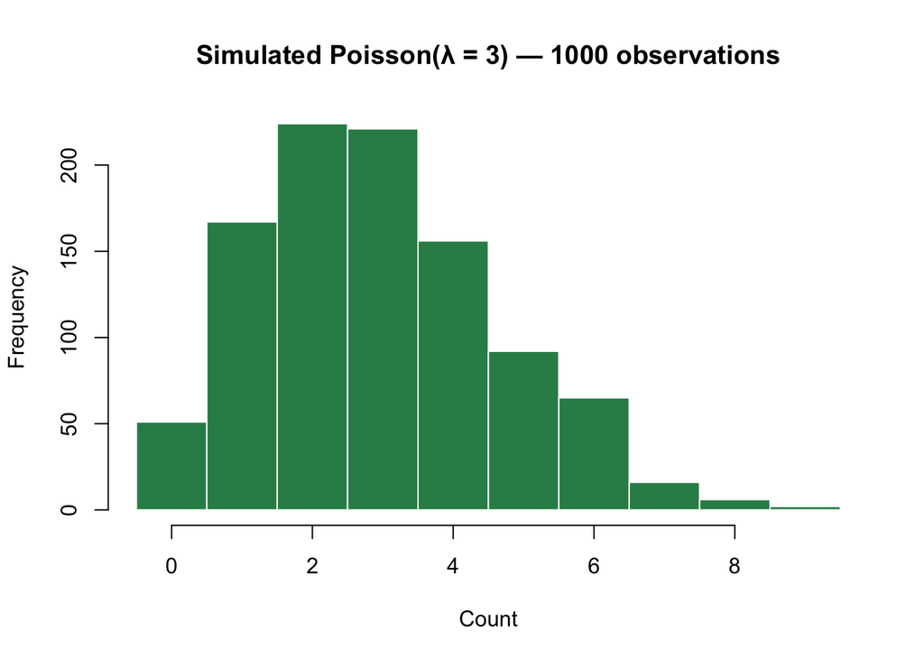

```r
# --- rpois(): simulate Poisson data ---
set.seed(42)
sim_pois <- rpois(1000, lambda = 3)

hist(sim_pois,
     breaks = -0.5:(max(sim_pois) + 0.5),
     col    = "seagreen",
     border = "white",
     main   = "Simulated Poisson(λ = 3) — 1000 observations",
     xlab   = "Count",
     ylab   = "Frequency")
```

## 5.3 `dnorm()`, `pnorm()`, `rnorm()`

```r
# --- dnorm(): height of the Normal PDF at a point ---
# This is NOT a probability — it's a density value
dnorm(0, mean = 0, sd = 1)   # peak of the standard normal
```

```
#> [1] 0.3989423
```

```r
# --- pnorm(): cumulative probability P(X <= x) ---
pnorm(1.96, mean = 0, sd = 1)   # ≈ 0.975 → 97.5% of data below 1.96
```

```
#> [1] 0.9750021
```

```r
# Verify the 95% rule: P(-1.96 <= X <= 1.96)
pnorm(1.96) - pnorm(-1.96)
```

```
#> [1] 0.9500042
```

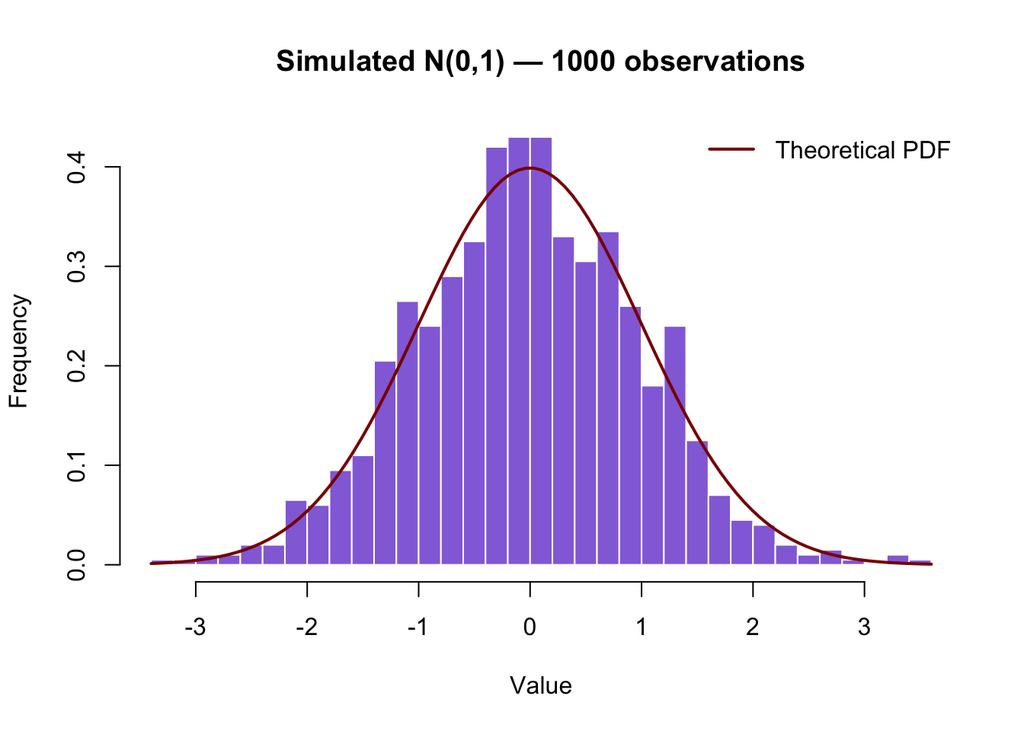

```r
# --- rnorm(): random samples from a Normal distribution ---
set.seed(42)
sim_norm <- rnorm(1000, mean = 0, sd = 1)

hist(sim_norm,
     breaks = 30,
     col    = "mediumpurple",
     border = "white",
     main   = "Simulated N(0,1) — 1000 observations",
     xlab   = "Value",
     ylab   = "Frequency",
     freq   = FALSE)
curve(dnorm(x), add = TRUE, col = "darkred", lwd = 2)
legend("topright", legend = "Theoretical PDF",
       col = "darkred", lwd = 2, bty = "n")
```

## 5.4 CLT Simulation

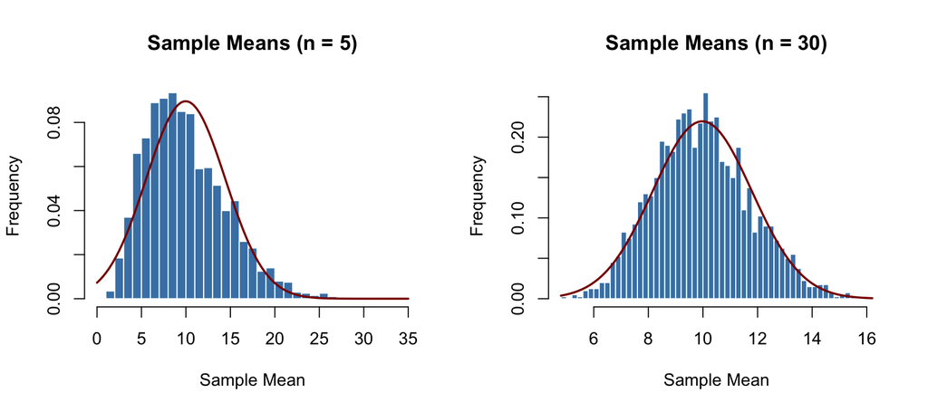

```r
set.seed(123)

# Skewed population: exponential distribution
population   <- rexp(100000, rate = 0.1)

num_samples  <- 2000
sample_sizes <- c(5, 30)     # compare small vs large n

par(mfrow = c(1, 2))

for (n in sample_sizes) {
  sample_means <- replicate(num_samples, mean(sample(population, n, replace = TRUE)))

  hist(sample_means,
       breaks = 40,
       col    = "steelblue",
       border = "white",
       main   = paste0("Sample Means (n = ", n, ")"),
       xlab   = "Sample Mean",
       ylab   = "Frequency",
       freq   = FALSE)

  # Overlay theoretical Normal curve
  curve(dnorm(x,
              mean = mean(population),
              sd   = sd(population) / sqrt(n)),
        add = TRUE, col = "darkred", lwd = 2)
}
```

```r
par(mfrow = c(1, 1))
```

> **Observe:** With $n = 5$, the distribution of sample means is still visibly skewed. By $n = 30$, it closely follows the red Normal curve — the CLT at work.

# 6 Chapter Summary

| Concept | Key Takeaway |
| --- | --- |
| Random Variable | Maps random outcomes to numbers; described by PMF (discrete) or PDF (continuous) |
| PMF | Exact probability at each value; all probabilities sum to 1 |
| PDF | Probability = area under the curve; point probability = 0 |
| Binomial $\text{Bin}(n,p)$ | Count of successes in $n$ independent trials |
| Poisson $\text{Poisson}(\lambda)$ | Count of rare events; mean = variance = $\lambda$ |
| Poisson ≈ Binomial | Valid when $n$ large, $p$ small, $\lambda = np$ |
| Uniform | Equal probability across $[a, b]$ |
| Normal $\mathcal{N}(\mu, \sigma^2)$ | Bell curve; 68–95–99.7 rule |
| CLT | Sample mean $\to$ Normal as $n \to \infty$, regardless of population shape |
| R: `d*()` | Density/mass at a point |
| R: `p*()` | Cumulative probability $P(X \leq x)$ |
| R: `r*()` | Random samples from the distribution |